# Quadratic Function

Lev Savolsky

## This is a markdown file

### Introduction

Hello, my name is Lev and I chose to describe you how to draw a graph of a simple quadratic function using **`plot()`** function in R as my Coursera project.

### Drawing

Firstly, we need to create a new R script, in R Studio - File -> New File -> R Script, or we can use Ctrl+Shift+N on Windows. In this file we’ll need to write a function **`Draw`**, for example:

```r
Draw <- function(x, y) {
    plot(x, y, type="l", xlab="x-axis", ylab="y-axis",
         main="Quadratic function")
}
```

As parameters for our function we take coordinates on the x-axis - **`x`** and a quadratic function - **`y`**. To draw our graphic we use function **`plot()`** here, as parameters we give our x and y variables, *type = “l”* stands for type of demonstration - lines, in *xlab* and *ylab* we write what should be shown next to the x-axis and y-axis, *main* parameter is the heading.

After we wrote our fuction we should run it first, then we go to the console in the bottom left of the screen, we initialize aour x and y variables like that:

```r
x <- (-10:10)
y <- 3*x^2 + 2*x + 4
```

We initialized *x* variable as a vector of integers to have a set of coordinates on our graph.

Now, finally, we can call our **`Draw(x, y)`** function and draw a graph of *3**x^2 + 2**x + 4* by writing:

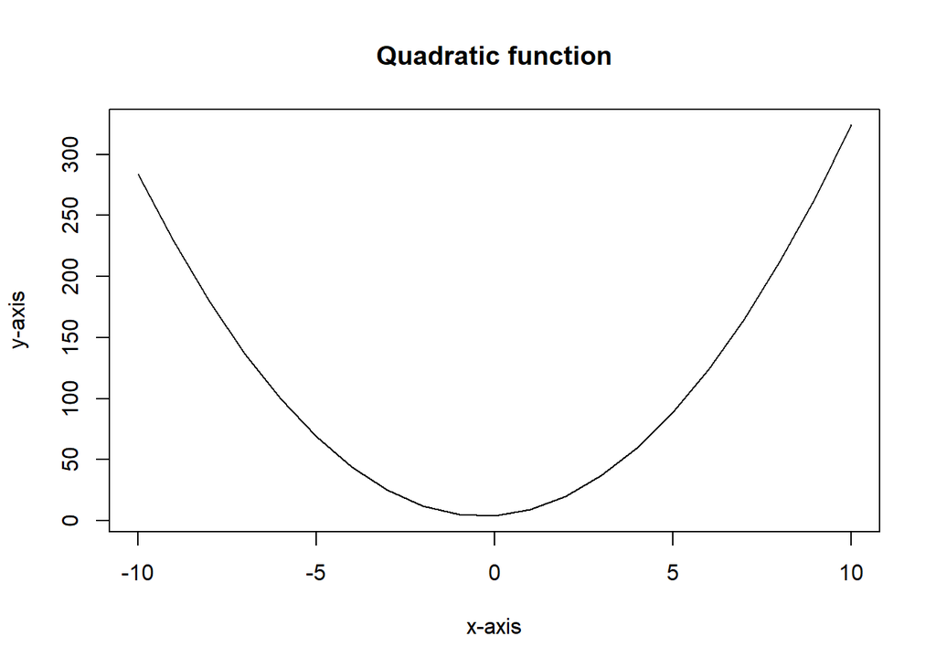

```r
Draw(x, y)
```

## *Thank you for reading and good luck on the next Data Science courses!*